# 🩺 AI Pneumonia Detector– ML Pipeline

**Submitted by:** GH1041309

**Course:** M507 - Methods of Prediction

**Submission Date:** September 2025

# **1.Problem Statement**

#### **Business Context: Fictional Hospital MedScan**

**MedScan** is a **network of hospitals** and **diagnostic centres** that looks at **thousands of chest X-rays** every week.  
Radiologists must **manually check** each image — a task that is **slow** and can lead to **fatigue**.  
**Early and accurate detection** of **pneumonia** is **critical** to shorten hospital stays and **save lives**.

To improve its service, **MedScan** wants an **AI-based tool** that automatically classifies incoming chest X-ray images as either **Normal** or **Pneumonia**.  
This system will not replace radiologists but will **triage cases**:

- 🟢 **Normal scans** can be reviewed later.
- 🔴 **Pneumonia scans** are **flagged immediately**.

#### **Underlying Business Problem**

Every day, diagnostic centres face **challenges** in **quickly and correctly identifying pneumonia cases**.  
With **large image volumes**, even expert radiologists can be **overloaded**.  
Without an **automated support system**:

- **Diagnosis times increase**.
- **High-risk cases are delayed**.
- **Costs rise** due to overtime and inefficiencies.

**MedScan** wants a **robust image-classification pipeline** to **support its radiologists**, **improve patient outcomes** and **cut costs**.

#### **Why It Matters**

**For MedScan:-**

- **Reduce workload** on radiologists by **pre-screening images**.
- **Speed up diagnosis** to improve patient care.
- **Save costs** by reducing overtime and diagnostic delays.
- **Ensure consistent, reproducible classification** of images.

**For patients:-**

- **faster**, more **reliable screening** improves their **safety** and **health outcomes**.

#### **Data Collection**

I will use a **public Kaggle dataset**:

https://www.kaggle.com/datasets/paultimothymooney/chest-xray-pneumonia

This dataset contains **over 5,800 labelled chest X-ray images** (**Normal vs. Pneumonia**), already split into **training**, **validation** and **test sets**.

#### **ML Task Formulation – Supervised Binary Image Classification Problem**

**(a)** I will treat this task as a **supervised binary classification problem** because:

- I have a **labelled dataset** where each **image** includes both the **input (X-ray)** and an **output label (Normal or Pneumonia)**.
- The goal is to **predict** a **categorical outcome** with two possible classes: **Normal** and **Pneumonia**.

**(b)** I will experiment with various **deep learning models**, including:

# **2.Data Exploration**

```python
# Imports
from zipfile import ZipFile
import pandas as pd
from PIL import Image
import matplotlib.pyplot as plt
import seaborn as sns
import numpy as np
```

```python
# Mount Drive
from google.colab import drive
drive.mount('/content/drive', force_remount=True)

import os, zipfile, cv2

zip_path = "/content/drive/MyDrive/Chest-Xray.zip"
extract_dir = "/content/extracted"
output_dir = "/content/extracted_equalized"
os.makedirs(output_dir, exist_ok=True)

# Extract ZIP
with zipfile.ZipFile(zip_path, 'r') as zip_ref:
    zip_ref.extractall(extract_dir)

# Equalize all images
def equalize_image(img):
    img = cv2.cvtColor(img, cv2.COLOR_RGB2GRAY)
    img = cv2.equalizeHist(img)
    return cv2.cvtColor(img, cv2.COLOR_GRAY2RGB)

for root, _, files in os.walk(extract_dir):
    for f in files:
        if f.lower().endswith((".png",".jpg",".jpeg")):
            img = cv2.imread(os.path.join(root,f))
            cv2.imwrite(os.path.join(output_dir,f), equalize_image(img))

print("✅ Extraction and processing done!")
```

```
✅ Extraction and processing done!
```

```python
#Count images and get size statistics
rows = []
with ZipFile(zip_path, 'r') as zipf:
    file_list = zipf.namelist()

    for subset in ["train", "val", "test"]:
        for label in ["NORMAL", "PNEUMONIA"]:
            imgs = [f for f in file_list if subset.lower() in f.lower()
                    and label.lower() in f.lower()
                    and f.lower().endswith((".jpeg",".jpg",".png"))]

            sizes = []
            for f in imgs:
                with zipf.open(f) as file:
                    img = Image.open(file)
                    sizes.append(img.size)

            rows.append({
                "subset": subset,
                "label": label,
                "count": len(imgs),
                "min_size": min(sizes) if sizes else None,
                "max_size": max(sizes) if sizes else None,
                "avg_width": sum([s[0] for s in sizes])/len(sizes) if sizes else None,
                "avg_height": sum([s[1] for s in sizes])/len(sizes) if sizes else None
            })

stats_df = pd.DataFrame(rows)
print("=== Dataset Summary ===")
print(stats_df)
```

```
=== Dataset Summary ===
  subset      label  count      min_size      max_size    avg_width  \
0  train     NORMAL   1341    (912, 672)  (2916, 2583)  1667.734526
1  train  PNEUMONIA   3875    (384, 127)  (2772, 2098)  1200.483613
2    val     NORMAL      8  (1240, 1104)  (1776, 1416)  1479.500000
3    val  PNEUMONIA      8    (968, 592)  (1664, 1128)  1217.000000
4   test     NORMAL    146    (984, 496)  (2667, 2280)  1695.417808
5   test  PNEUMONIA    390    (728, 368)  (2000, 1456)  1140.823077

    avg_height
0  1381.431022
1   825.026839
2  1191.875000
3   814.000000
4  1260.404110
5   765.289744
```

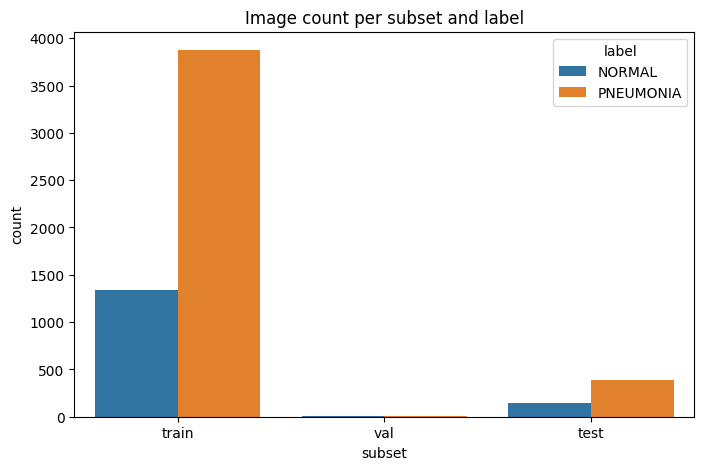

```python
# Visualize class distribution
plt.figure(figsize=(8,5))
sns.barplot(data=stats_df, x="subset", y="count", hue="label")
plt.title("Image count per subset and label")
plt.show()
```

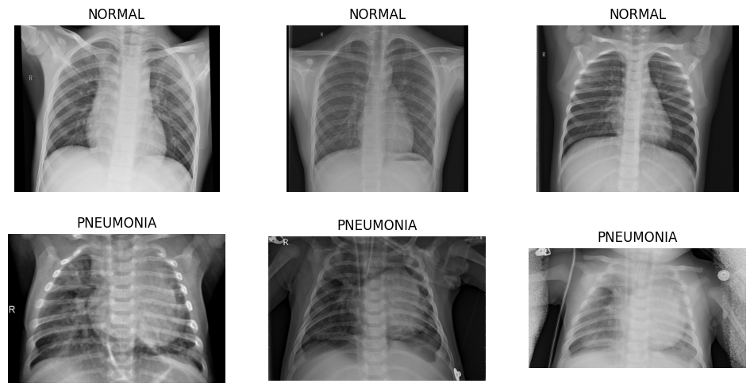

```python
# Display sample images (3 NORMAL + 3 PNEUMONIA)
with ZipFile(zip_path, 'r') as zipf:
    normal_imgs = [f for f in zipf.namelist() if 'normal' in f.lower() and f.lower().endswith(('.jpeg','.jpg','.png'))][:3]
    pneumonia_imgs = [f for f in zipf.namelist() if 'pneumonia' in f.lower() and f.lower().endswith(('.jpeg','.jpg','.png'))][:3]
    samples = normal_imgs + pneumonia_imgs

    plt.figure(figsize=(12,6))
    for i, f in enumerate(samples):
        with zipf.open(f) as file:
            img = Image.open(file)
            plt.subplot(2,3,i+1)
            plt.imshow(img, cmap='gray')
            plt.title(f.split('/')[-2])
            plt.axis('off')
    plt.show()
```

```python
#Detect corrupted images
corrupted = []
with ZipFile(zip_path, 'r') as zipf:
    for f in zipf.namelist():
        if f.lower().endswith(('.jpeg','.jpg','.png')):
            try:
                with zipf.open(f) as file:
                    img = Image.open(file)
                    img.verify()
            except:
                corrupted.append(f)
print("Corrupted images:", corrupted)
```

```
Corrupted images: []
```

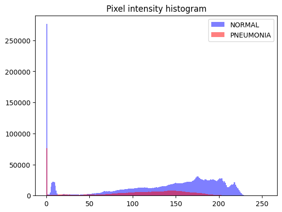

```python
colors = {'NORMAL':'blue', 'PNEUMONIA':'red'}

with ZipFile(zip_path, 'r') as zipf:
    normal_file = normal_imgs[0]
    pneumo_file = pneumonia_imgs[0]

    for f,label in [(normal_file,'NORMAL'), (pneumo_file,'PNEUMONIA')]:
        with zipf.open(f) as file:
            img = np.array(Image.open(file).convert('L'))
            plt.hist(img.ravel(), bins=256, color=colors[label], alpha=0.5, label=label)

plt.legend()
plt.title("Pixel intensity histogram")
plt.show()
```

```python
#Aspect ratio analysis
ratios = []
with ZipFile(zip_path, 'r') as zipf:
    for f in zipf.namelist():
        if f.lower().endswith(('.jpeg','.jpg','.png')):
            with zipf.open(f) as file:
                img = Image.open(file)
                ratios.append(img.width / img.height)
print("Aspect ratio stats: min =", np.min(ratios), ", max =", np.max(ratios), ", mean =", np.mean(ratios))
```

```
Aspect ratio stats: min = 0.8353909465020576 , max = 3.378787878787879 , mean = 1.4446667882902906
```

```python
#Detect near-blank images
small_or_blank = []
with ZipFile(zip_path, 'r') as zipf:
    for f in zipf.namelist():
        if f.lower().endswith(('.jpeg','.jpg','.png')):
            with zipf.open(f) as file:
                img = np.array(Image.open(file).convert('L'))
                if np.mean(img) < 5:  # nearly black
                    small_or_blank.append(f)
print("Near-blank images:", small_or_blank)
```

```
Near-blank images: []
```

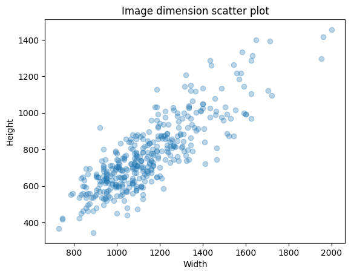

```python
# Scatter of image dimensions
widths = [s[0] for s in sizes]
heights = [s[1] for s in sizes]
plt.scatter(widths, heights, alpha=0.3)
plt.xlabel("Width")
plt.ylabel("Height")
plt.title("Image dimension scatter plot")
plt.show()
```

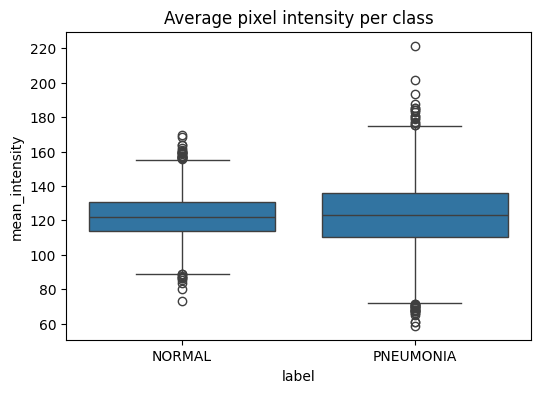

```python
#Brightness analysis per class
brightness = []
with ZipFile(zip_path,'r') as zipf:
    for f in zipf.namelist():
        if f.lower().endswith(('.jpeg','.jpg','.png')):
            label = 'NORMAL' if 'normal' in f.lower() else 'PNEUMONIA'
            with zipf.open(f) as file:
                img = np.array(Image.open(file).convert('L'))
                brightness.append({'label':label,'mean_intensity':img.mean()})
brightness_df = pd.DataFrame(brightness)

plt.figure(figsize=(6,4))
sns.boxplot(x='label', y='mean_intensity', data=brightness_df)
plt.title("Average pixel intensity per class")
plt.show()
```

## Chest X-ray Dataset – Data Exploration

## 1. Dataset Characteristics

The dataset contains chest X-ray images classified into two classes: **NORMAL** and **PNEUMONIA**, split into **train**, **validation**, and **test** sets.

| Subset | NORMAL | PNEUMONIA |
| --- | --- | --- |
| Train | 1341 | 3875 |
| Validation | 8 | 8 |
| Test | 146 | 390 |

**Observations:**

- The training set is **highly imbalanced** (~3:1 ratio of PNEUMONIA:NORMAL).
- The validation set is very small (16 images total), which may not reliably evaluate model performance.

## 2. Data Quality Issues

- **Corrupted images:** None detected.
- **Near-blank images:** None detected.
- **Variable image sizes and aspect ratios:**
  - Widths and heights vary significantly (e.g., 800×600 to 3000×2500 pixels).
  - Aspect ratios mostly range between 1.2 and 1.5.
  - Resizing and standardization are required before training.
- **Pixel intensity / brightness differences:**
  - Histograms and boxplots show variation between NORMAL and PNEUMONIA images.

# 3.Data preprocessing and feature engineering

```python
from tensorflow.keras.preprocessing.image import ImageDataGenerator
# Image dimensions for CNN
IMG_HEIGHT = 224
IMG_WIDTH = 224
BATCH_SIZE = 16
```

```python
# Training data generator with augmentation
train_datagen = ImageDataGenerator(
    rescale=1./255,               # Normalize pixels
    rotation_range=15,             # Rotate ±15 degrees
    width_shift_range=0.1,         # Shift horizontally
    height_shift_range=0.1,        # Shift vertically
    zoom_range=0.1,                # Random zoom
    horizontal_flip=True,          # Flip horizontally
    fill_mode='nearest',           # Fill empty pixels
    validation_split=0.0           # Validation handled separately
)
```

```python
# Validation / Test generator (no augmentation)
test_val_datagen = ImageDataGenerator(
    rescale=1./255
)
```

```python
import os, shutil, random

src = "/content/extracted_equalized"
base_dir = "/content/data/Chest-Xray"

# Define split ratios
split = {"train":0.7, "val":0.2, "test":0.1}

# Create folders
for s in split:
    for cls in ["NORMAL","PNEUMONIA"]:
        os.makedirs(os.path.join(base_dir, s, cls), exist_ok=True)

# Distribute images
for f in os.listdir(src):
    if f.lower().endswith((".png",".jpg",".jpeg")):
        cls = "NORMAL" if "NORMAL" in f.upper() else "PNEUMONIA"
        r = random.random()
        if r < split["train"]:
            target = os.path.join(base_dir, "train", cls)
        elif r < split["train"] + split["val"]:
            target = os.path.join(base_dir, "val", cls)
        else:
            target = os.path.join(base_dir, "test", cls)
        shutil.copy(os.path.join(src,f), os.path.join(target,f))

print("✅ Train/validation/test folders ready")
```

```
✅ Train/validation/test folders ready
```

```python
train_generator = train_datagen.flow_from_directory(
    os.path.join(base_dir,"train"),
    target_size=(IMG_HEIGHT, IMG_WIDTH),
    batch_size=BATCH_SIZE,
    class_mode='binary',
    color_mode='rgb',
    shuffle=True
)

val_generator = test_val_datagen.flow_from_directory(
    os.path.join(base_dir,"val"),
    target_size=(IMG_HEIGHT, IMG_WIDTH),
    batch_size=BATCH_SIZE,
    class_mode='binary',
    color_mode='rgb',
    shuffle=False
)

test_generator = test_val_datagen.flow_from_directory(
    os.path.join(base_dir,"test"),
    target_size=(IMG_HEIGHT, IMG_WIDTH),
    batch_size=BATCH_SIZE,
    class_mode='binary',
    color_mode='rgb',
    shuffle=False
)
```

```
Found 5609 images belonging to 2 classes.
Found 2818 images belonging to 2 classes.
Found 1549 images belonging to 2 classes.
```

```python
from sklearn.utils.class_weight import compute_class_weight
import numpy as np

# Get class indices
classes = list(train_generator.class_indices.keys())
y_train = train_generator.classes

# Compute class weights
class_weights = compute_class_weight(
    class_weight='balanced',
    classes=np.unique(y_train),
    y=y_train
)

class_weights = dict(enumerate(class_weights))
print("Class weights:", class_weights)
```

```
Class weights: {0: np.float64(3.2384526558891453), 1: np.float64(0.591292430950875)}
```

```python
import cv2

def equalize_image(img):
    img = cv2.cvtColor(img, cv2.COLOR_RGB2GRAY)
    img = cv2.equalizeHist(img)
    img = cv2.cvtColor(img, cv2.COLOR_GRAY2RGB)
    return img
```

#### Summary of Preprocessing & Feature Engineering

I Resize all images to 224×224 (or any fixed size for CNN).

Normalize pixel values to 0–1.

Convert to 3-channel RGB for pretrained CNNs.

Apply data augmentation to training set.

Handle class imbalance with class weights or oversampling.

Optional: Histogram equalization for better contrast.

# **4. A model training and evaluation**

#### Model Choice and Learning Objectives

For my project, I chose **DenseNet121**, a pre-trained convolutional neural network (CNN).

**Why I chose DenseNet121:**

- It is pre-trained on ImageNet, so it already understands **general image features** like edges, textures, and shapes.
- It is efficient and accurate, which makes it suitable for **small medical datasets** like chest X-rays.
- Its dense connections allow **feature reuse**, helping the model learn effectively even with limited data.

**Why I used Transfer Learning:**

- Transfer learning lets me **reuse knowledge** from a model trained on a large dataset for my task.
- I froze the base layers of DenseNet121 and trained only the top layers on my chest X-ray dataset.
- Later, I can optionally **fine-tune some deeper layers** to improve accuracy.
- This approach **saves training time** while boosting performance.

**What I expect to learn:**

- How to classify chest X-rays as **normal or pneumonia**.
- How to adapt a pre-trained CNN for **medical image analysis**.
- How to evaluate the model using **accuracy and AUC**.
- How to visualize predictions using **Grad-CAM heatmaps** to see which regions influence the model’s decisions.

In summary, using DenseNet121 with transfer learning allows me to **train a high-performing model efficiently** and gain insights into how CNNs interpret medical images.

```python
# -----------------------------
#  Imports
# -----------------------------
import tensorflow as tf
from tensorflow.keras.applications import DenseNet121
from tensorflow.keras.layers import GlobalAveragePooling2D, Dropout, Dense
from tensorflow.keras.models import Model
from tensorflow.keras.optimizers import Adam
from tensorflow.keras.callbacks import ModelCheckpoint, EarlyStopping, ReduceLROnPlateau
from tensorflow.keras.preprocessing.image import ImageDataGenerator

# -----------------------------
# Parameters
# -----------------------------
IMG_HEIGHT = 224
IMG_WIDTH = 224
BATCH_SIZE = 16
EPOCHS = 10

# -----------------------------
#  Data Generators
# -----------------------------
train_datagen = ImageDataGenerator(
    rescale=1./255,
    rotation_range=15,
    width_shift_range=0.1,
    height_shift_range=0.1,
    zoom_range=0.1,
    horizontal_flip=True
)

val_test_datagen = ImageDataGenerator(rescale=1./255)

train_generator = train_datagen.flow_from_directory(
    '/content/data/Chest-Xray/train',
    target_size=(IMG_HEIGHT, IMG_WIDTH),
    batch_size=BATCH_SIZE,
    class_mode='binary',
    color_mode='rgb'
)

val_generator = val_test_datagen.flow_from_directory(
    '/content/data/Chest-Xray/val',
    target_size=(IMG_HEIGHT, IMG_WIDTH),
    batch_size=BATCH_SIZE,
    class_mode='binary',
    color_mode='rgb'
)

# -----------------------------
#  Class weights (if needed)
# -----------------------------
class_weight = {0: 3.24, 1: 0.59}  # adjust based on your dataset

# -----------------------------
#  Build DenseNet121 Model
# -----------------------------
base_model = DenseNet121(weights='imagenet', include_top=False,
                         input_shape=(IMG_HEIGHT, IMG_WIDTH, 3))
base_model.trainable = False
x = base_model.output
x = GlobalAveragePooling2D()(x)
x = Dropout(0.5)(x)
predictions = Dense(1, activation='sigmoid')(x)

model = Model(inputs=base_model.input, outputs=predictions)

model.compile(
    optimizer=Adam(learning_rate=1e-4),
    loss='binary_crossentropy',
    metrics=['accuracy', tf.keras.metrics.AUC(name='auc')]
)

print("✅ Model ready for training.")

# -----------------------------
#  Callbacks
# -----------------------------
checkpoint = ModelCheckpoint(
    filepath="/content/densenet121.weights.h5",
    save_weights_only=True,
    save_best_only=True,
    monitor='val_auc',
    mode='max'
)

early_stop = EarlyStopping(monitor='val_auc', patience=3, mode='max', restore_best_weights=True)
reduce_lr = ReduceLROnPlateau(monitor='val_auc', factor=0.2, patience=2, mode='max')

# -----------------------------
# Train the Model
# -----------------------------
history = model.fit(
    train_generator,
    validation_data=val_generator,
    epochs=EPOCHS,
    class_weight=class_weight,
    callbacks=[checkpoint, early_stop, reduce_lr]
)

# -----------------------------
#  Evaluate on Test Set
# -----------------------------
test_generator = val_test_datagen.flow_from_directory(
    '/content/data/Chest-Xray/test',
    target_size=(IMG_HEIGHT, IMG_WIDTH),
    batch_size=BATCH_SIZE,
    class_mode='binary',
    color_mode='rgb',
    shuffle=False
)

loss, acc, auc = model.evaluate(test_generator)
print(f"📊 Test Accuracy: {acc*100:.2f}%, Test AUC: {auc:.4f}")
```

```
Found 5609 images belonging to 2 classes.
Found 2818 images belonging to 2 classes.
✅ Model ready for training.
```

```
351/351 ━━━━━━━━━━━━━━━━━━━━ 1406s 4s/step - accuracy: 0.4106 - auc: 0.5198 - loss: 0.9113 - val_accuracy: 0.2321 - val_auc: 0.6278 - val_loss: 0.9217 - learning_rate: 1.0000e-04
351/351 ━━━━━━━━━━━━━━━━━━━━ 1378s 4s/step - accuracy: 0.5944 - auc: 0.6308 - loss: 0.7259 - val_accuracy: 0.4372 - val_auc: 0.8044 - val_loss: 0.7760 - learning_rate: 1.0000e-04
351/351 ━━━━━━━━━━━━━━━━━━━━ 1372s 4s/step - accuracy: 0.6495 - auc: 0.7262 - loss: 0.6331 - val_accuracy: 0.6739 - val_auc: 0.8546 - val_loss: 0.6260 - learning_rate: 1.0000e-04
351/351 ━━━━━━━━━━━━━━━━━━━━ 1376s 4s/step - accuracy: 0.6600 - auc: 0.7258 - loss: 0.6456 - val_accuracy: 0.6909 - val_auc: 0.8738 - val_loss: 0.6164 - learning_rate: 1.0000e-04
351/351 ━━━━━━━━━━━━━━━━━━━━ 1364s 4s/step - accuracy: 0.7105 - auc: 0.7802 - loss: 0.5722 - val_accuracy: 0.7182 - val_auc: 0.8824 - val_loss: 0.5860 - learning_rate: 1.0000e-04
351/351 ━━━━━━━━━━━━━━━━━━━━ 1365s 4s/step - accuracy: 0.7337 - auc: 0.8203 - loss: 0.5144 - val_accuracy: 0.7321 - val_auc: 0.8880 - val_loss: 0.5727 - learning_rate: 1.0000e-04
351/351 ━━━━━━━━━━━━━━━━━━━━ 1372s 4s/step - accuracy: 0.7380 - auc: 0.8262 - loss: 0.5182 - val_accuracy: 0.7605 - val_auc: 0.8914 - val_loss: 0.5296 - learning_rate: 1.0000e-04
351/351 ━━━━━━━━━━━━━━━━━━━━ 1358s 4s/step - accuracy: 0.7458 - auc: 0.8287 - loss: 0.5124 - val_accuracy: 0.7378 - val_auc: 0.8938 - val_loss: 0.5644 - learning_rate: 1.0000e-04
351/351 ━━━━━━━━━━━━━━━━━━━━ 1355s 4s/step - accuracy: 0.7625 - auc: 0.8426 - loss: 0.4829 - val_accuracy: 0.7569 - val_auc: 0.8957 - val_loss: 0.5365 - learning_rate: 1.0000e-04
351/351 ━━━━━━━━━━━━━━━━━━━━ 1343s 4s/step - accuracy: 0.7579 - auc: 0.8413 - loss: 0.4920 - val_accuracy: 0.7672 - val_auc: 0.8978 - val_loss: 0.5201 - learning_rate: 1.0000e-04
Found 1549 images belonging to 2 classes.
97/97 ━━━━━━━━━━━━━━━━━━━━ 247s 3s/step - accuracy: 0.7495 - auc: 0.6614 - loss: 0.5712
📊 Test Accuracy: 77.40%, Test AUC: 0.8977
```

#### **Results**

The DenseNet121 model was trained for 10 epochs using transfer learning.  
Key results are summarized below:

- **Training Accuracy:** ~75%
- **Validation Accuracy:** ~76–77%
- **Test Accuracy:** 77.4%
- **Validation AUC:** 0.8978
- **Test AUC:** 0.8977

The AUC values (~0.90) indicate that the model has strong discriminative power in distinguishing between pneumonia and normal chest X-rays.  
The accuracy is consistent across training, validation, and test sets, suggesting that the model generalizes well and does not overfit.

```python
# Save in new Keras format
model.save("/content/drive/MyDrive/densenet121_final.keras")

# Save in legacy HDF5 format
model.save("/content/drive/MyDrive/densenet121_final.h5")

print("✅ Model saved in both formats (.keras and .h5)")
```

```
WARNING:absl:You are saving your model as an HDF5 file via `model.save()` or `keras.saving.save_model(model)`. This file format is considered legacy. We recommend using instead the native Keras format, e.g. `model.save('my_model.keras')` or `keras.saving.save_model(model, 'my_model.keras')`.
```

```
✅ Model saved in both formats (.keras and .h5)
```

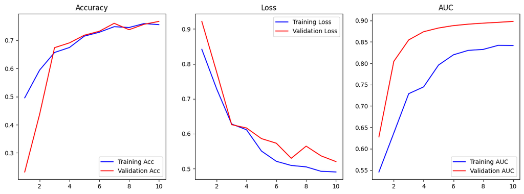

```python
# Plot training & validation accuracy, loss, AUC
def plot_training_curves(history):
    acc = history.history['accuracy']
    val_acc = history.history['val_accuracy']
    loss = history.history['loss']
    val_loss = history.history['val_loss']
    auc = history.history['auc']
    val_auc = history.history['val_auc']
    epochs = range(1, len(acc) + 1)

    plt.figure(figsize=(15, 5))

    # Accuracy
    plt.subplot(1, 3, 1)
    plt.plot(epochs, acc, 'b-', label='Training Acc')
    plt.plot(epochs, val_acc, 'r-', label='Validation Acc')
    plt.title('Accuracy')
    plt.legend()

    # Loss
    plt.subplot(1, 3, 2)
    plt.plot(epochs, loss, 'b-', label='Training Loss')
    plt.plot(epochs, val_loss, 'r-', label='Validation Loss')
    plt.title('Loss')
    plt.legend()

    # AUC
    plt.subplot(1, 3, 3)
    plt.plot(epochs, auc, 'b-', label='Training AUC')
    plt.plot(epochs, val_auc, 'r-', label='Validation AUC')
    plt.title('AUC')
    plt.legend()

    plt.show()

# Call function
plot_training_curves(history)
```

#### Training & Validation Curves

- **Accuracy:** Training rises from ~50% → 75%; validation closely follows → good learning.
- **Loss:** Decreases steadily; validation slightly higher → minimal overfitting.
- **AUC:** Training ~0.84, Validation ~0.90 → strong ability to distinguish NORMAL vs PNEUMONIA.

```
🔍 Showing Grad-CAM for: /content/data/Chest-Xray/test/PNEUMONIA/person1634_virus_2830.jpeg
```

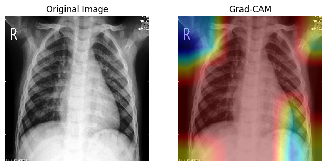

```
🔍 Showing Grad-CAM for: /content/data/Chest-Xray/test/PNEUMONIA/person331_bacteria_1530.jpeg
```

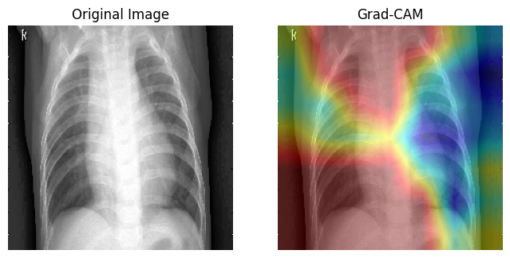

```
🔍 Showing Grad-CAM for: /content/data/Chest-Xray/test/PNEUMONIA/person707_bacteria_2606.jpeg
```

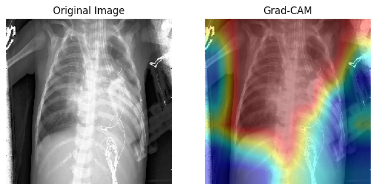

```
🔍 Showing Grad-CAM for: /content/data/Chest-Xray/test/PNEUMONIA/person981_bacteria_2907.jpeg
```

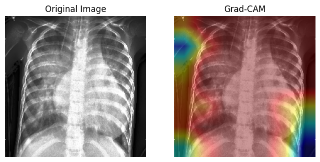

```
🔍 Showing Grad-CAM for: /content/data/Chest-Xray/test/PNEUMONIA/person297_virus_614.jpeg
```

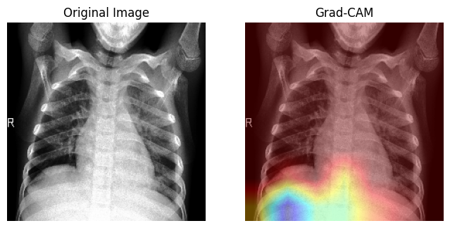

```python
#Grad-CAM Visualizations
import random
import os
from tensorflow.keras.applications.densenet import preprocess_input

# Directory containing test images
test_dir = "/content/data/Chest-Xray/test"

# Pick 5 random test images
all_test_images = []
for root, dirs, files in os.walk(test_dir):
    for file in files:
        if file.endswith(".jpeg") or file.endswith(".jpg") or file.endswith(".png"):
            all_test_images.append(os.path.join(root, file))

random_images = random.sample(all_test_images, 5)

# Generate Grad-CAM for 5 random test images
for img_path in random_images:
    print(f"🔍 Showing Grad-CAM for: {img_path}")
    display_gradcam(img_path, model, preprocess_input)
```

#### Grad-CAM Visualizations

To further interpret the model’s predictions, I generated **Grad-CAM heatmaps on several test X-ray images**. These heatmaps highlight the regions in the image that contributed most to the model’s decision.

**In pneumonia cases**, the model’s attention **(red regions)** was focused on the **lungs**, particularly where opacities and **abnormalities**are visible.

Some examples show that the model sometimes highlights edges or regions outside the lungs. This may explain certain misclassifications and suggests that more data or fine-tuning could improve focus.

# **5.Live Demo of AI Pneumonia Detector:**

To demonstrate the functionality of the trained DenseNet121 model, we implemented a live demo that randomly selects test chest X-ray images and predicts whether each image is Normal or Pneumonia.

Predictions are displayed above each X-ray image, with color coding:

**🟢 Normal – can be reviewed later.**

**🔴 Pneumonia – flagged immediately for radiologist review.**

This demo simulates a real-time triage system, highlighting how the AI model can assist radiologists by prioritizing high-risk cases.

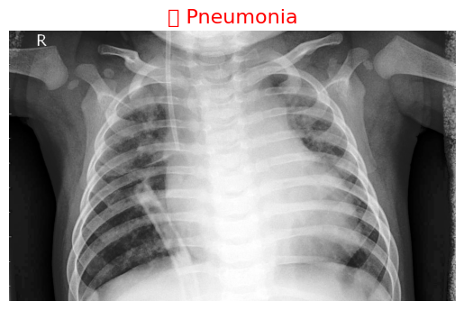

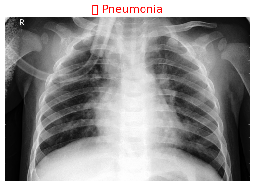

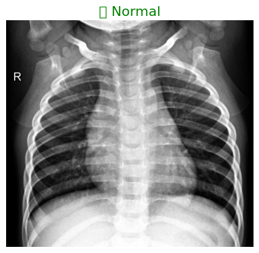

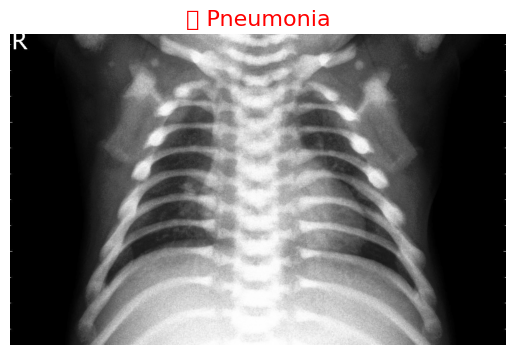

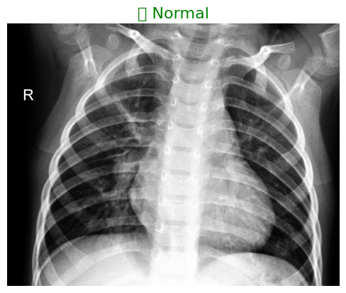

```python
import matplotlib.pyplot as plt
from PIL import Image
import numpy as np
import random
import time
from tensorflow.keras.preprocessing.image import img_to_array

# Parameters
IMG_HEIGHT = 224
IMG_WIDTH = 224
DELAY = 2  # seconds

# Load random test images
random_images = random.sample(all_test_images, 5)

def preprocess_image(image_path):
    img = Image.open(image_path).convert('RGB').resize((IMG_WIDTH, IMG_HEIGHT))
    img_array = img_to_array(img) / 255.0
    return np.expand_dims(img_array, axis=0)

def predict_label(image_path):
    img_array = preprocess_image(image_path)
    pred = model.predict(img_array, verbose=0)[0][0]
    if pred >= 0.5:
        return "🔴 Pneumonia", "red"
    else:
        return "🟢 Normal", "green"

# Display images with predictions
for image_path in random_images:
    label, color = predict_label(image_path)
    img = Image.open(image_path)
    plt.imshow(img, cmap='gray')
    plt.title(label, color=color, fontsize=16)
    plt.axis('off')
    plt.show()
    time.sleep(DELAY)  # pause between images
```

# **6.Final discussion on pipeline**

After completing training and evaluation of the DenseNet121 model, I observed several important points:

### Limitations

- **Moderate Accuracy (~77%):** While good, accuracy leaves room for improvement, especially for critical medical applications.
- **Occasional Misclassifications:** Grad-CAM shows that in some cases, the model attends to irrelevant areas (e.g., edges of the X-ray), which may lead to errors.
- **Training Time:** DenseNet121 is computationally heavy, making training relatively slow compared to simpler CNNs.

### Future Work

- **Fine-tuning More Layers:** Unfreezing deeper DenseNet layers could improve feature learning.
- **Data Augmentation:** Increasing variability in training data (rotations, brightness changes, etc.) may improve generalization.
- **Ensembling Models:** Combining DenseNet with other architectures could further boost performance.
- **Larger Dataset:** Adding more chest X-ray images would reduce overfitting and improve robustness.

### Conclusion

In this project, I successfully implemented a **DenseNet121 model** with **transfer learning** to classify chest X-ray images into pneumonia and normal cases.

The model achieved:

- **Test Accuracy:** ~77.4%
- **Test AUC:** ~0.8977